# HW04 Part 1: Complete Chapter 3

Donovan Kleinberg

25 December 2018

## Chapter 3

- Change “your name” in the YAML header above to your name.

### Section 3.1

Load the tidyverse packages. I’ve entered the first code chunk for you. **You must enter all subsequent code chunks and run the code.**

```r
library("tidyverse")
```

If you get an error, then you did not install the `tidyverse` package like you were supposed to in the previous assignment. Go back to that assignment and complete that step. (This should not be the case, though.)

### Section 3.2: First steps

Enter your code chunks for Section 3.2 here.

Get in the habit of entering a brief description of what each chunk of code does. Enter this above the chunk, like I did in Section 3.1.

The chunk displays a table of mpg data.

```r
ggplot2::mpg
```

| manufacturer | model | displ | year | cyl | trans | drv | cty | hwy | fl | class |
| --- | --- | --- | --- | --- | --- | --- | --- | --- | --- | --- |
| audi | a4 | 1.8 | 1999 | 4 | auto(l5) | f | 18 | 29 | p | compact |
| audi | a4 | 1.8 | 1999 | 4 | manual(m5) | f | 21 | 29 | p | compact |
| audi | a4 | 2.0 | 2008 | 4 | manual(m6) | f | 20 | 31 | p | compact |
| audi | a4 | 2.0 | 2008 | 4 | auto(av) | f | 21 | 30 | p | compact |
| audi | a4 | 2.8 | 1999 | 6 | auto(l5) | f | 16 | 26 | p | compact |
| audi | a4 | 2.8 | 1999 | 6 | manual(m5) | f | 18 | 26 | p | compact |
| audi | a4 | 3.1 | 2008 | 6 | auto(av) | f | 18 | 27 | p | compact |
| audi | a4 quattro | 1.8 | 1999 | 4 | manual(m5) | 4 | 18 | 26 | p | compact |
| audi | a4 quattro | 1.8 | 1999 | 4 | auto(l5) | 4 | 16 | 25 | p | compact |
| audi | a4 quattro | 2.0 | 2008 | 4 | manual(m6) | 4 | 20 | 28 | p | compact |

[output cut: 224 more lines]

```r
dim(mpg)
```

```
[1] 234  11
```

Descriptions of variables for mpg are shown.

```r
?mpg
```

Chunk shows a plot of hwy vs cyl.

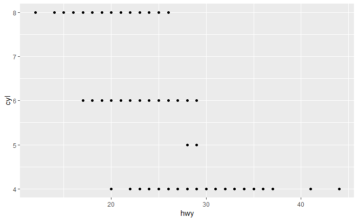

```r
ggplot(data = mpg) +
  geom_point(mapping = aes(x = hwy, y = cyl))
```

Chunk shows a plot of class vs drv.

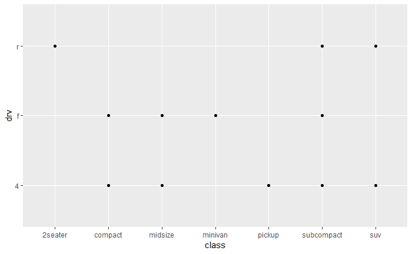

```r
ggplot(data = mpg) +
  geom_point(mapping = aes(x = class, y = drv))
```

Example 1. Chunk shows a plot of displ vs hwy.

```r
ggplot(data = mpg) +
  geom_point(mapping = aes(x = displ, y = hwy))
```

[output not shown]

#### Section 3.2 Questions

Answer the questions *completely.* Some answers will require you to write code in a code chunk and also to type text before or after the chunk. Other answers will require only code or only text.

**1:** Run ggplot(data = mpg). What do you see? Answer for question 1: A table with car manufacturers, models and relevant engine data is displayed.

**2:** How many rows are in `mpg`? How many columns? **Hint:** Use the `dim()` function. Type `dim()` in the console to learn what `dim()` does. Answer for question 2: 234 rows, 11 columns.

**3:** What does the `drv` variable describe? Read the help for `?mpg` to find out. Answer for question 3: drv describes whether a car is forward, rear or all wheel drive.

**4:** Make a scatterplot of `hwy` vs `cyl`. Answer for question 4: Scatterplot made.

**5:** What happens if you make a scatterplot of `class` vs `drv`? Why is the plot not useful? Answer for question 5: This plot doesn’t give anything really useful for statistical comparison.

### Section 3.3: Aesthetic mappings

Chunk has various plots.

```r
ggplot(data = mpg) +
  geom_point(mapping = aes(x = trans, y = cty, color = cty))

ggplot(data = mpg) +
  geom_point(mapping = aes(x = trans, y = hwy, size = hwy))

ggplot(data = mpg) +
  geom_point(mapping = aes(x = cyl, y = cty, shape = cty))
```

[output not shown]

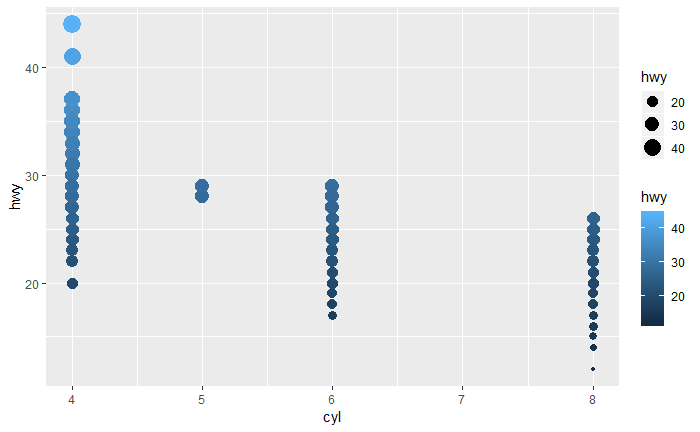

```r
ggplot(data = mpg) +
  geom_point(mapping = aes(x = cyl, y = hwy, size = hwy, color = hwy))
```

Chunk describes functions of aesthetics and plots a graph with a thick stroke.

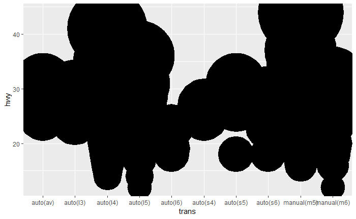

```r
?geom_point
vignette("ggplot2-specs")
ggplot(data = mpg) +
  geom_point(mapping = aes(x = trans, y = hwy, stroke = hwy))
```

Chunk prints out a table of class vs. drv with a true/false color assignment based on cyl >5.

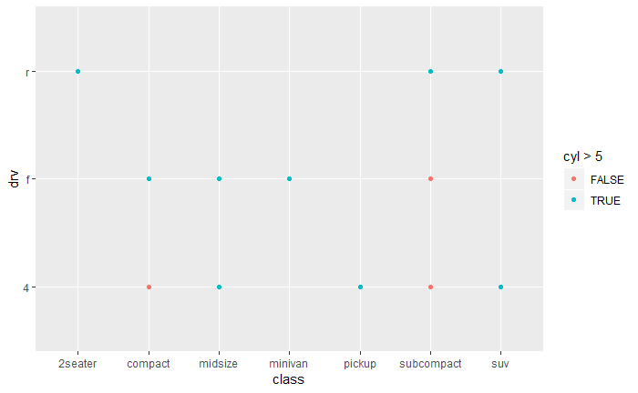

```r
ggplot(data = mpg) +
  geom_point(mapping = aes(x = class, y = drv, color = cyl >5))
```

Example 1: This chunk plots displ vs hwy with colors assigned to class.

```r
ggplot(data = mpg) +
  geom_point(mapping = aes(x = displ, y = hwy, color = class))
```

[output not shown]

Example 2: Chunk displays plots with varying transparency first and varying shape in the second plot.

```r
ggplot(data = mpg) +
  geom_point(mapping = aes(x = displ, y = hwy, alpha = class))

ggplot(data = mpg) +
  geom_point(mapping = aes(x = displ, y = hwy, shape = class))
```

[output not shown]

Example 3: This chunk prints a plot with all dots colored blue as a manual aesthetic not linked to a variable.

```r
ggplot(data = mpg) +
  geom_point(mapping = aes(x = displ, y = hwy), color = "blue")
```

[output not shown]

#### Section 3.3 questions

**1:** What’s gone wrong with this code? Why are the points not blue? Answer for question 1: In order to make all points blue without tying them to a variable the code should be in a parentheses outside of aes ().

**2:** Which variables in `mpg` are categorical? Which variables are continuous? (*Hint:* type `?mpg` to read the documentation for the dataset). How can you see this information when you run mpg? Answer for question 2: displ, cty and hwy are continuous variables. model, year, cyl, trans, fl and class are catergorical.

**3:** Map a continuous variable to color, size, and shape. How do these aesthetics behave differently for categorical vs. continuous variables? **Note:** You need several code chunks here to answer this question. Answer for question 3: The shape map will not work with continuous variables as shapes are badly suited to show changes on a gradient. Chunk shows various plots modelled with different colors, sizes and shapes.

**4:** What happens if you map the same variable to multiple aesthetics? Answer to question 4: Assuming the map works with continuous variables the two combine on the plot.

**5:** What does the stroke aesthetic do? What shapes does it work with? (*Hint:* use `?geom_point`) Answer for question 5: Stroke controls how thick the borders of a filled shape are.

**6:** What happens if you map an aesthetic to something other than a variable name, like `aes(colour = displ < 5)`? Answer for question 6: The graph will have color assigned on a true/false basis of the qualifying factor.

### Section 3.5: Facets

Chunk used for 1. prediction.

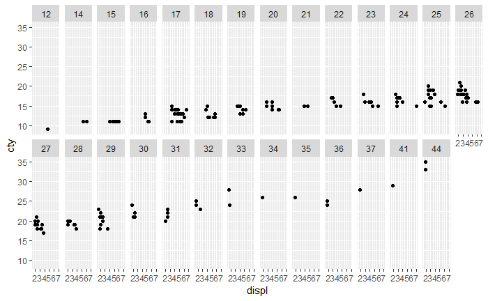

```r
ggplot(data = mpg) +
  geom_point(mapping = aes(x = displ, y = cty)) +
  facet_wrap(~ hwy, nrow = 2)
```

Chunk has several plots illustrating the “.” being used

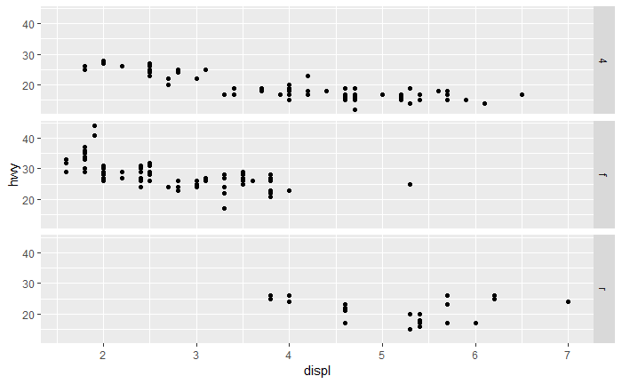

```r
ggplot(data = mpg) +
  geom_point(mapping = aes(x = displ, y = hwy)) +
  facet_grid(drv ~ .)
```

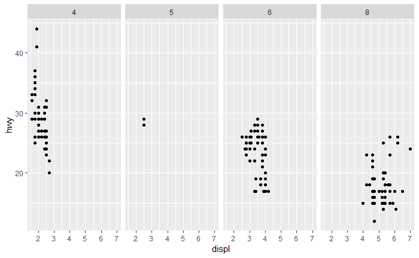

```r
ggplot(data = mpg) +
  geom_point(mapping = aes(x = displ, y = hwy)) +
  facet_grid(. ~ cyl)
```

This chunk brings up the functions of facet_wrap.

```r
?facet_wrap
```

Example 1: This chunk is a facet_grid of drv vs cyl.

```r
ggplot(data = mpg) +
  geom_point(mapping = aes(x = displ, y = hwy)) +
  facet_grid(drv ~ cyl)
```

[output not shown]

#### Section 3.5 questions

**1:** What happens if you facet on a continuous variable? **Note:** Write a prediction, then make and run your code chunk. Answer for question 1: I predict that I will receive an error message saying that facetting doesn’t apply to continuous variables.

**2:** What do the empty cells in plot with `facet_grid(drv ~ cyl)` mean? How do they relate to this plot? Answer for question 2: The empty cells show that there are no data points within that type of wrap. For example there are no data points collected using a 4 cyl, r drive car and as such that grid is left empty.

**3:** What plots does the following code make? What does `.` do? Answer for question 3: The chunk displays plots of displ vs hwy. The . replaces a variable and allows the code to only facet on one dimension, either x or y with the other dimension represented by . not being faceted.

**4:** Take the first faceted plot below. What are the advantages to using faceting instead of the colour aesthetic? What are the disadvantages? How might the balance change if you had a larger dataset? Answer for question 4: Faceting allows for catergorical data to be viewed separately and helps reduce clutter while simply using a color aesthetic can result in data being very crowded. Colored datasets can help provide a larger picture however, while faceting splits data up. As data becomes larger I believe faceting becomes more important to help pull out data from a large and cluttered sample size.

**5:** Read `?facet_wrap`. What does `nrow` do? What does `ncol` do? What other options control the layout of the individual panels? Why doesn?ft `facet_grid()` have nrow and ncol argument? Answer for question 5: nrows and ncols sets the number of rows and columns in the plot. Other options are drop, dir, strip.position, labeller and as.table. facet_grid has facets for more than one variable which prevents manual setting of ncol or nrow.

**6:** When using `facet_grid()` you should usually put the variable with more unique levels in the columns. Why? Answer for question 6: It will make the data less jumbled and easier to read.

### Section 3.6: Geometric objects

Chunk used for 2. predictions.

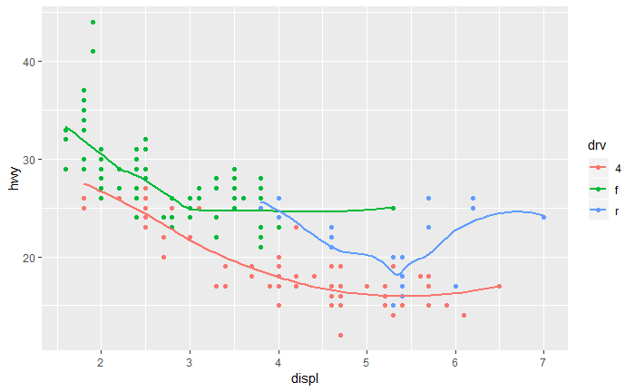

```r
ggplot(data = mpg, mapping = aes(x = displ, y = hwy, color = drv)) +
  geom_point() +
  geom_smooth(se = FALSE)
```

Chunk shows comparison for 5.

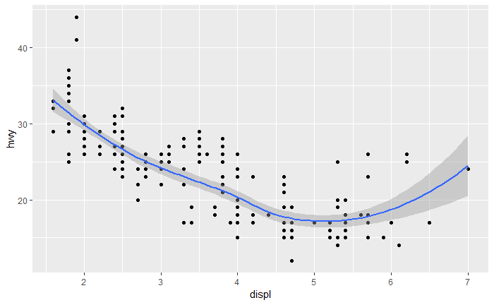

```r
ggplot(data = mpg, mapping = aes(x = displ, y = hwy)) +
  geom_point() +
  geom_smooth()
```

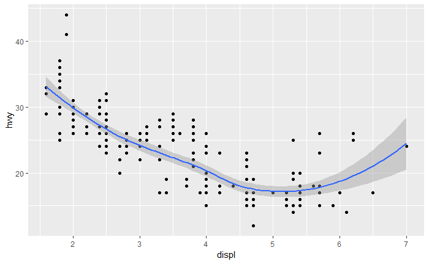

```r
ggplot() +
  geom_point(data = mpg, mapping = aes(x = displ, y = hwy)) +
  geom_smooth(data = mpg, mapping = aes(x = displ, y = hwy))
```

#### Section 3.6.1 Questions

**1:** What geom would you use to draw a line chart? A boxplot? A histogram? An area chart? **Note:** You will have to make some types of these charts in Part 2 of this assignment. Answer for question 1: I’d use geom_line for a linechart, geom_boxplot for a boxplot, geom_histogram for a histogram and geom_area for an area chart.

**2:** Run this code in your head and predict what the output will look like. Then, run the code in R and check your predictions. Answer for question 2: A plot of displ vs hwy will be shown broken into drv which will each be different colors. There will be points and a line for each with no standard error. My predictions were very close, the only major difference was that the line served to show the median of the values.

**3:** What does `show.legend = FALSE` do? What happens if you remove it? **Note:** Skip the “Why do you think I used it earlier in the chapter?” question. Answer for question 3: Show.legend = false removes the legend from a plot or graph. When used the legend is removed leaving just the plot or graph.

**4:** What does the `se` argument to `geom_smooth()` do? Answer for question 4: The se argument determines whether or not a shaded area that represents the standard error of deviation for the data is shown on the graph.

**5:** Will these two graphs look different? Why/why not? Answer for question 5: I do think they will be the same, the graphs use the same arguments but the first one is more condensed.

**6:** Recreate the R code necessary to generate the following graphs. **Note:** Enter a separate code chunk for each graph, numbered 1 to 6, starting row-wise at upper left.

1: upper left.

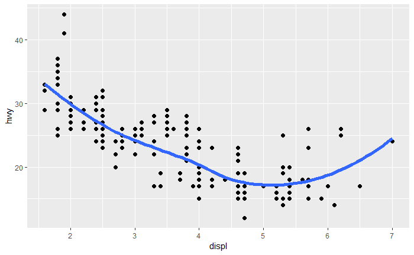

```r
### 1.
ggplot(data = mpg, mapping = aes(x = displ, y = hwy)) +
  geom_point(size = 2) +
  geom_smooth(size = 2, se = FALSE)
```

2: upper right.

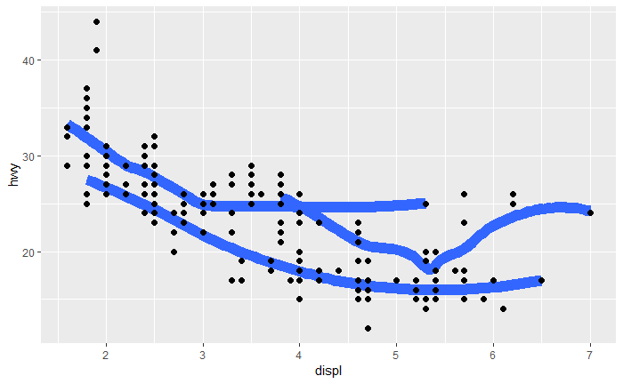

```r
ggplot(data = mpg,mapping = aes(x = displ, y = hwy)) +
  geom_smooth(mapping = aes(group = drv, size = 2), se = FALSE, show.legend = FALSE) +
  geom_point(size = 2)
```

3: middle left.

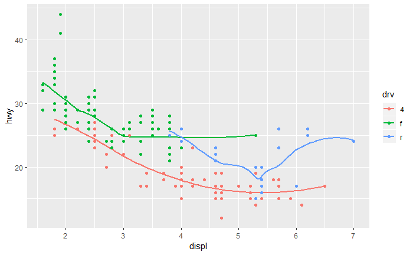

```r
ggplot(data = mpg, mapping = aes(x = displ, y = hwy)) +
  geom_smooth(mapping = aes(color = drv), show.legend = TRUE, se = FALSE) +
  geom_point(mapping = aes(color = drv), show.legend = TRUE)
```

4: middle right.

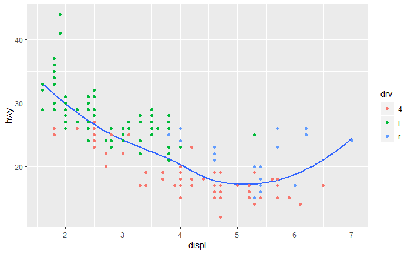

```r
ggplot(data = mpg, mapping = aes(x = displ, y = hwy)) +
  geom_smooth(show.legend = FALSE, se = FALSE) +
  geom_point(mapping = aes(color = drv), show.legend = TRUE)
```

5: lower left.

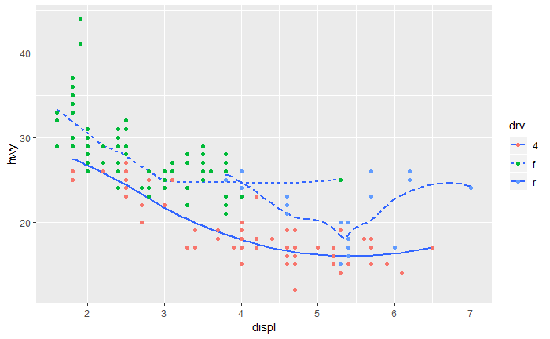

```r
ggplot(data = mpg, mapping = aes(x = displ, y = hwy)) +
  geom_smooth(mapping = aes(group = drv, linetype = drv), show.legend = TRUE, se = FALSE) +
  geom_point(mapping = aes(color = drv), show.legend = TRUE)
```

6: lower right. *Hint:* Read the help file for `geom_point`. Use `shape = 21`, `stroke = 2`, and `size = 3`.

[figure not shown]

```r
ggplot(data = mpg, mapping = aes(x = displ, y = hwy)) +
  geom_point(mapping = aes(size = 5), show.legend = FALSE, color = "white") +
  geom_point(mapping = aes(color = drv), show.legend = TRUE)
```

### Section 3.7: Statistical transformations.

**Skip this section.** We may return to it later.

### Section 3.8 Position adjustments

This chunk has improved code for 1.

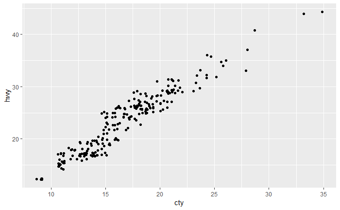

```r
ggplot(data = mpg, mapping = aes(x = cty, y = hwy)) +
  geom_point(mapping = aes(), position = "jitter")
```

Chunk is visualization for 4.

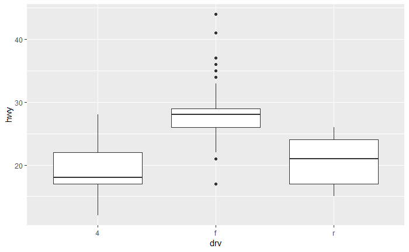

```r
### Default plot
ggplot(data = mpg, mapping = aes(x = drv, y = hwy)) +
  geom_boxplot()
```

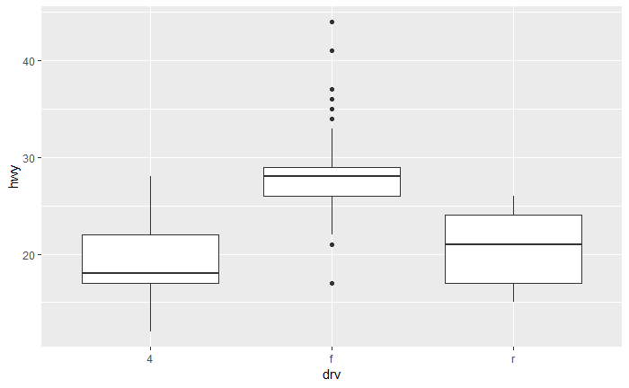

```r
### Plot that looks the same with dodge as position
ggplot(data = mpg, mapping = aes(x = drv, y = hwy)) +
  geom_boxplot(position = "dodge")
```

#### Section 3.8 Questions

**1:** What is the problem with this plot? How could you improve it. *Hint:* Remember the size of the `mpg` data set from earlier in this exercise. Does the number of points seem correct? **Note:** Write the code to improve it. Answer for question 1: The plot has too much data on it to show all the data points. Adding jitter will allow for the data to be seen.

**2:** What parameters to `geom_jitter()` control the amount of jittering? Answer for question 2: The parameters width and height control the jitter.

**3:** Compare and contrast `geom_jitter()` with `geom_count()`. Answer for question 3: Both are used to help plots deal with overplotting. geom_jitter adds a set amount of randomness to the data to display them all while geom_count counts the number of observations and carefully plots them in a certain area.

**4:** What is the default position adjustment for `geom_boxplot()`? Create a visualization of the `mpg` dataset that demonstrates it. Answer for question 4: Position = dodge is default for geom_boxplots.

### Section 3.9: Coordinate systems

**Note:** Read about and do only the code chunk associated with `coord_flip()`. `coord_flip()` is a great layer to use when you have categorical data with longish names as it makes the text easier to read.

### Section 3.10: The layered grammar of graphics

Just read this section as a contextual review of everything you just learned.